# 08 STAT 213 Review

Author

Ben Sunshine

## 2/11/24

## 8.1

```r
library(tidyverse)
library(broom)
library(here)
theme_set(theme_minimal())
```

```r
library(palmerpenguins)
penguins
```

```
# A tibble: 344 × 8
   species island    bill_length_mm bill_depth_mm flipper_length_mm body_mass_g
   <fct>   <fct>              <dbl>         <dbl>             <int>       <int>
 1 Adelie  Torgersen           39.1          18.7               181        3750
 2 Adelie  Torgersen           39.5          17.4               186        3800
 3 Adelie  Torgersen           40.3          18                 195        3250
 4 Adelie  Torgersen           NA            NA                  NA          NA
 5 Adelie  Torgersen           36.7          19.3               193        3450
 6 Adelie  Torgersen           39.3          20.6               190        3650
 7 Adelie  Torgersen           38.9          17.8               181        3625
 8 Adelie  Torgersen           39.2          19.6               195        4675
 9 Adelie  Torgersen           34.1          18.1               193        3475
10 Adelie  Torgersen           42            20.2               190        4250
# ℹ 334 more rows
# ℹ 2 more variables: sex <fct>, year <int>
```

```
#> # A tibble: 344 × 8
#>   species island   bill_length_mm bill_depth_mm flipper_length_mm body_mass_g
#>   <fct>   <fct>             <dbl>         <dbl>             <int>       <int>
#> 1 Adelie  Torgers…           39.1          18.7               181        3750
#> 2 Adelie  Torgers…           39.5          17.4               186        3800
#> 3 Adelie  Torgers…           40.3          18                 195        3250
#> 4 Adelie  Torgers…           NA            NA                  NA          NA
#> 5 Adelie  Torgers…           36.7          19.3               193        3450
#> 6 Adelie  Torgers…           39.3          20.6               190        3650
#> # ℹ 338 more rows
#> # ℹ 2 more variables: sex <fct>, year <int>
```

Exercise 1. Examine the penguins data set in the palmerpenguins package: Fit a linear regression model with body_mass_g as the response variable and species and bill_length_mm as the predictors. Note that penguins with missing values for any of these three variables will be dropped from the analysis.

```r
penguin_mod <- lm(body_mass_g ~ species + bill_length_mm, data = penguins)
```

Exercise 2. Create a table of summary output, including coefficient estimates, standard errors, test statistics, and p-values, using one of the broom functions.

```r
broom::tidy(penguin_mod)
```

```
# A tibble: 4 × 5
  term             estimate std.error statistic  p.value
  <chr>               <dbl>     <dbl>     <dbl>    <dbl>
1 (Intercept)         154.     269.       0.572 5.68e- 1
2 speciesChinstrap   -886.      88.3    -10.0   6.37e-21
3 speciesGentoo       579.      75.4      7.68  1.76e-13
4 bill_length_mm       91.4      6.89    13.3   1.16e-32
```

Exercise 3. Use glance() to glance at some of the relevant model statistics.

```r
glance(penguin_mod)
```

```
# A tibble: 1 × 12
  r.squared adj.r.squared sigma statistic   p.value    df logLik   AIC   BIC
      <dbl>         <dbl> <dbl>     <dbl>     <dbl> <dbl>  <dbl> <dbl> <dbl>
1     0.783         0.781  375.      406. 1.03e-111     3 -2511. 5031. 5050.
# ℹ 3 more variables: deviance <dbl>, df.residual <int>, nobs <int>
```

Exercise 4. Using augment(), create a plot of the residuals vs. the fitted values and evaluate the constant variance assumption.

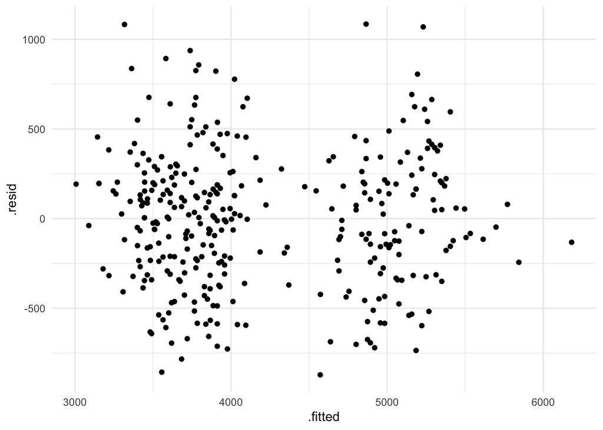

```r
augment(penguin_mod) %>%
  ggplot(aes(x = .fitted, y = .resid)) +
  geom_point()
```

Exercise 5. Using augment(), check to see if there are any penguins that are influential. Use 0.75 as your cut-off value for Cook’s distance.

```r
augment(penguin_mod) %>%
  filter(.cooksd >= 0.75)
```

```
# A tibble: 0 × 10
# ℹ 10 variables: .rownames <chr>, body_mass_g <int>, species <fct>,
#   bill_length_mm <dbl>, .fitted <dbl>, .resid <dbl>, .hat <dbl>,
#   .sigma <dbl>, .cooksd <dbl>, .std.resid <dbl>
```

- There are no observations at or above the 0.75 threshold.